# Activity Prediction Project

Adithya Murali

April 3, 2016

## Background

Using devices such as JawboneUp, NikeFuelBand, and Fitbitit is now possible to collect a large amount of data about personal activity relatively inexpensively. These type of devices are part of the quantified self movement - a group of enthusiasts who take measurements about themselves regularly to improve their health, to find patterns in their behavior, or because they are tech geeks. One thing that people regularly do is quantify how much of a particular activity they do, but they rarely quantify how well they do it.

In this project, the goal is to use data from accelerometers on the belt, forearm, arm, and dumbell of 6 participants. They were asked to perform barbell lifts correctly and incorrectly in 5 different ways. More information is available from the website: http://groupware.les.inf.puc-rio.br/har (see the section on the Weight Lifting Exercise Dataset).

## Data Loading

First, we load the dervied data from accelerometers, that we will use to build our prediction model, and check the dimensions of the dataframe.

```r
## Download files from web if missing
if (!file.exists("./data/pml-training.csv")) {
  download.file("https://d396qusza40orc.cloudfront.net/predmachlearn/pml-training.csv",
                destfile="./data/pml-training.csv", method="curl")
}
if (!file.exists("./data/pml-testing.csv")) {
  download.file("https://d396qusza40orc.cloudfront.net/predmachlearn/pml-testing.csv",
                destfile="./data/pml-testing.csv", method="curl")
}
pmltraining = read.csv("./data/pml-training.csv");
pmltesting = read.csv("./data/pml-testing.csv");
dim(pmltraining)
```

```
## [1] 19622   160
```

As shown above, there are 160 columns and 19622 observations.

```r
names(pmltraining)
```

After checking the names of the columns, output hidden for readability, we see that there is one column for target outcome `classe`.

## Data Cleaning

First, we observe the target outcome or `classe` variable from our model training data.

```r
classe.outcome= pmltraining[, "classe"]
levels(classe.outcome)
```

```
## [1] "A" "B" "C" "D" "E"
```

There are five levels of `classe` variable: `A`, `B`, `C`, `D`, `E`

```r
filter = grepl("belt|arm|forearm|dumbell", names(pmltraining))
cleanedTrain = pmltraining[, filter]
cleanedTest = pmltesting[, filter]
cleanedTrain$classe = classe.outcome
```

To impove accuracy with our prediction we remove all columns with NA values.

```r
valid.cols = colSums(is.na(cleanedTest)) == 0
cleanedTrain = cleanedTrain[, valid.cols]
cleanedTest = cleanedTest[, valid.cols]
```

Check amount of predictors in resulting data frame

```r
table(complete.cases(cleanedTrain))
```

```
##
##  TRUE
## 19622
```

```r
table(sapply(cleanedTrain[1,], class))
```

```
##
##  factor integer numeric
##       1      19      20
```

There are 19622 complete observations with 39 integer or numeric columns and one factor column, containing our target outcome.

## Data Preprocessing

We set our seed for reproducibility and load `caret` package needed for pre-processing and later for model building.

```r
library(caret)
set.seed(1500)
```

Not to be confused with our `pmltesting` data, as part of our preprocessing we split our `pmltraining` dataset into a `training` and `testing` dataset. This way, as we build our prediction model using `training` dataset we can validate it using our `testing` dataset, where we know the outcome, before performing predictions with `pmltesting`.

```r
inTrain <- createDataPartition(y=cleanedTrain$classe, p=0.60, list=FALSE)
training <- cleanedTrain[inTrain,]
testing <- cleanedTrain[-inTrain,]
```

## Data Exploration

We load libraries for rendering plots.

```r
library(ggplot2) ##for exploration
library(corrplot) ##for exploration
```

We graph the relationship between our numeric or integer column values vs. our factor variable, the outcome.

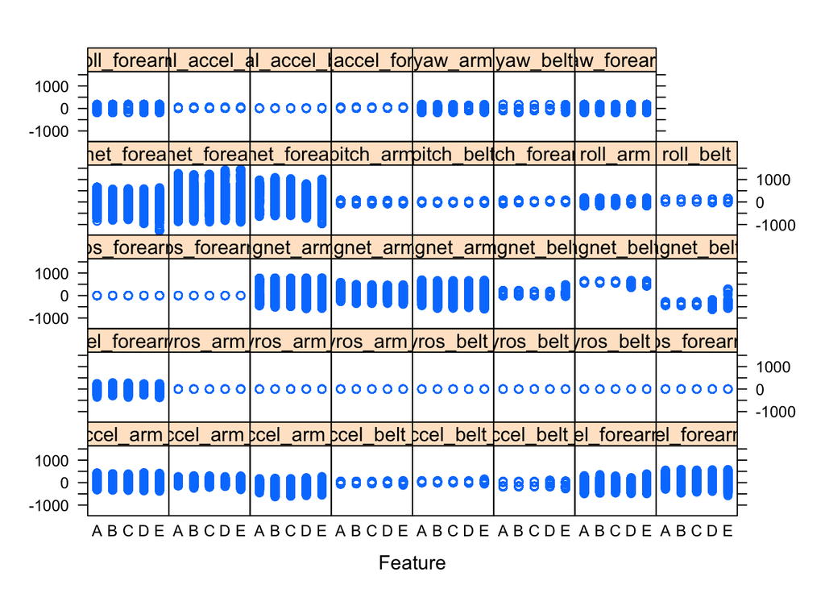

```r
featurePlot(training[,1:(ncol(training)-1)], training[,"classe"], "strip")
```

We also plot a correlation matrix containing all of our features.

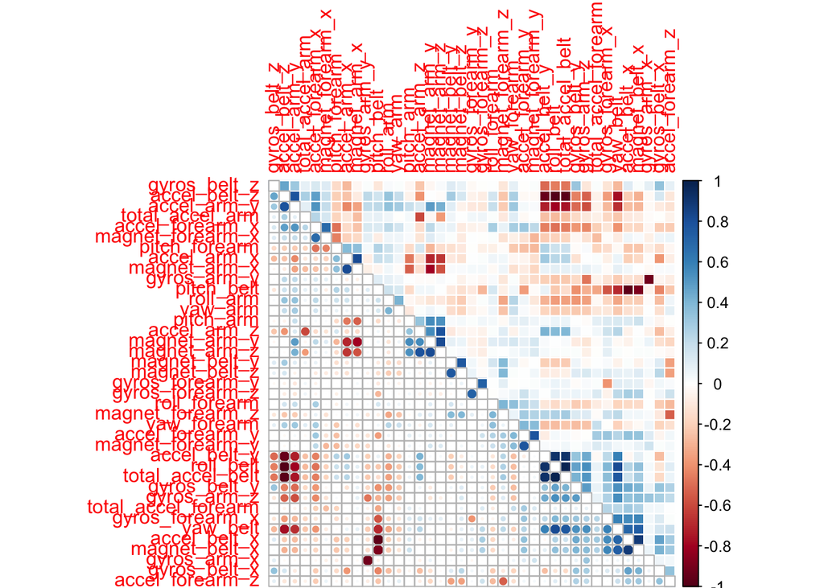

```r
corrplot.mixed(cor(training[,1:(ncol(training)-1)]), lower="circle", upper="color",
               tl.pos="lt", diag="n", order="hclust", hclust.method="complete")
```

## Model Building

Lets use `random forest` to create our prediction model. First, we load the needed libraries.

```r
library(randomForest)
```

Since random forest have a downside of over-fitting, it is important that we use some cross validation.

```r
rfmodel.control <- trainControl(method="cv", number=4, verboseIter=F) ##4-fold cross-validation
rfmodel.fit <- train(classe ~ ., data=training, method="rf", trControl=rfmodel.control)
```

Let us examine the final model as part of random forest model fit.

```r
rfmodel.fit$finalModel
```

```
##
## Call:
##  randomForest(x = x, y = y, mtry = param$mtry)
##                Type of random forest: classification
##                      Number of trees: 500
## No. of variables tried at each split: 2
##
##         OOB estimate of  error rate: 1.21%
## Confusion matrix:
##      A    B    C    D    E class.error
## A 3342    3    0    3    0 0.001792115
## B   11 2255   13    0    0 0.010530935
## C    0   43 1989   22    0 0.031645570
## D    0    1   37 1889    3 0.021243523
## E    0    1    1    5 2158 0.003233256
```

We get an accuracy of `98.79%`.

## Model Validation

Lets use our random forest model from the previous step and calculate our **out of sample error** using the `testing` dataset we set aside from our `pmltraining` data.

```r
predictedTesting <- predict(rfmodel.fit, newdata = testing)
confusionMatrix(predictedTesting, testing$classe)
```

```
## Confusion Matrix and Statistics
##
##           Reference
## Prediction    A    B    C    D    E
##          A 2225    6    2    0    0
##          B    7 1505   39    1    0
##          C    0    7 1315   18    2
##          D    0    0   11 1267    1
##          E    0    0    1    0 1439
##
## Overall Statistics
##
##                Accuracy : 0.9879
##                  95% CI : (0.9852, 0.9902)
##     No Information Rate : 0.2845
##     P-Value [Acc > NIR] : < 2.2e-16
##
##                   Kappa : 0.9847
##  Mcnemar's Test P-Value : NA
##
## Statistics by Class:
##
##                      Class: A Class: B Class: C Class: D Class: E
## Sensitivity            0.9969   0.9914   0.9613   0.9852   0.9979
## Specificity            0.9986   0.9926   0.9958   0.9982   0.9998
## Pos Pred Value         0.9964   0.9697   0.9799   0.9906   0.9993
## Neg Pred Value         0.9988   0.9979   0.9919   0.9971   0.9995
## Prevalence             0.2845   0.1935   0.1744   0.1639   0.1838
## Detection Rate         0.2836   0.1918   0.1676   0.1615   0.1834
## Detection Prevalence   0.2846   0.1978   0.1710   0.1630   0.1835
## Balanced Accuracy      0.9977   0.9920   0.9785   0.9917   0.9989
```

The average accuracy is `98.79%`, with **out of sample error** rate of `1.21%`.

## Test Data Predictions

With **out of sample error** rate less than `1.5%`, lets use this model on our test data from `pmltesting`.

```r
predictionOnSampleTest <- predict(rfmodel.fit, newdata = pmltesting)
write.table(predictionOnSampleTest, file="pmltesting_predictions.txt", quote=F, row.names=F, col.names=F)
```